# Crimes Analysis in Seatlle and San Francisco in summer 2014

RDSN

30 November 2015

## Digging into the Seattle and San Francisco datasets released

We will go trhough all those statements in detail in this paper.

If you want to see the report with code, it’s all available at this link : [report with code](http://rpubs.com/rdsn/131997) or at the link under each figure.

## Datasets overview

First, we load the datasets, recorded in a .csv format, and see what we are provided with.

- These datasets report crimes appearing in the city of Seattle and San Francisco, in the summer 2014, from June to August 2014.
- Each dataset contains different pieces of information, such as location, date and time, crimes categories. Those pieces of information are reported in each city in a different way. For example, crimes categories are not the same in the Seattle and San Francisco report. That means that we will have to manipulate features so to enable a proper comparison before those two datasets.
- Once we have transformed those pieces of information such as to be able to perform comparison, we can analyze crimes through time, through categories, and through cities.

First, let’s transform those variables and create a single dataframe so that to compare values for those two cities.

In order to create this signle dataframe, we have to convert all the crimes descriptions in each dataset so that both cities present the same categories.  
To do so, we have collected the National Incident-Based Reporting System (NIBRS) data, which categorize crimes into universal categories.  
This dataset can be found here : http://data.denvergov.org/download/gis/crime/csv/offense_codes.csv  
The NIBRS data contains 15 high categories of crimes, and 294 sub-categories.  
As we can observe from the Seattle and the San Francisco datasets :

- Seattle data : 48 categories and 147 sub-categories
- San Francisco data : 34 categories and 368 sub-categories. For the purpose of this analysis, we are going to fit categories in each of the datasets with the 15 categories from the NIBRS dataset.

Let’s make a plot of this whole new dataset.

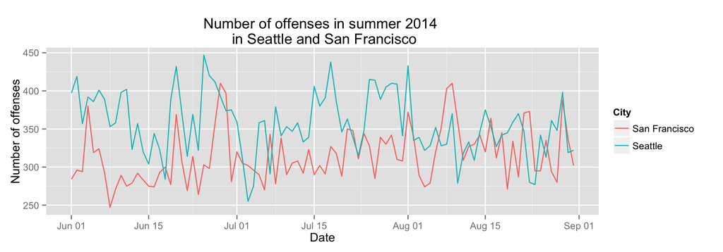

[report with code](http://rpubs.com/rdsn/131997)

This plot seems to tell us that the number of offenses is higher in Seattle than in San Francisco. Indeed, we could have noticed before that the number of records in the Seattle dataset (32 779) is higher than in the San Francisco dataset (28 993). This trend may be just due to the fact that the number of people living in Seattle is greater than the ones living in San Francisco.  
Let’s check.

- Seattle : [668 342](https://en.wikipedia.org/wiki/Demographics_of_Seattle)
- San Francisco : [805 235](https://suburbanstats.org/population/california/how-many-people-live-in-san-francisco)

So if we plot again the evolution of the number of offenses over time, but this time taking into account the population, and so plotting this time the number of offenses per capita, here is what we get.

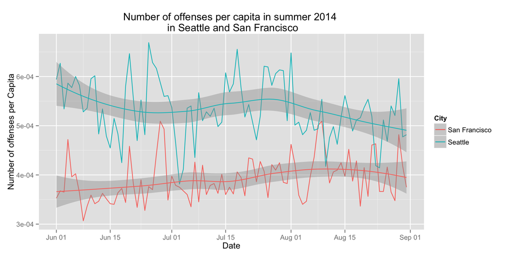

[report with code](http://rpubs.com/rdsn/131997)

Let’s notice that we have here plotted a smooth curve representing the trend for each city.  
This plot allows us to understand that there are more offenses happening in summer 2014 in Seatlle than in San Francisco, this not being due to the demographics. Indeed, Seattle counts less inhabitants than San Francisco, that fact deeping the gap between the two cities in terms of number of offenses.

Let’s dig deeper.

## Types of offenses

Now we are going to watch the different types of offenses, trying to understand what kind happens the most. Let’s have alook first at the general distribution, accross both cities.

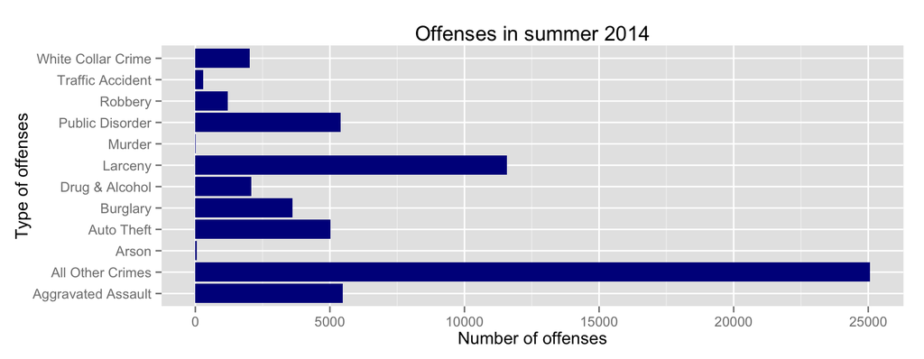

[report with code](http://rpubs.com/rdsn/131997)

Do those categories are the same in both cities?

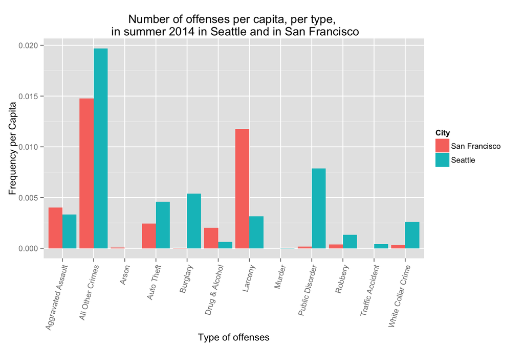

[report with code](http://rpubs.com/rdsn/131997)

Here we see clearly that, appart from the category “All Other Crimes” for which in both cities the frequency is high, trends depend upon cities.  
In Seattle, we observe that “Larceny” is far less occuring than in San Francisco. On the opposite, “Public Disorder” is far more occuring in Seattle while in San Francisco it stays relatively marginal.

## Time evolution of offenses

We can go further and watch those types of offenses month by month.

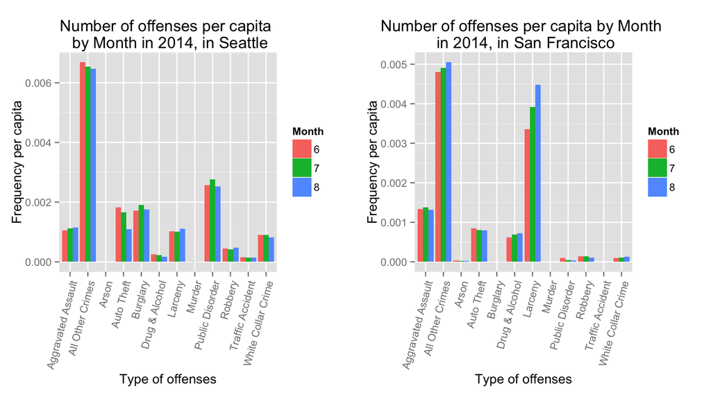

[report with code](http://rpubs.com/rdsn/131997)

This plot gives us an overview of the offenses’evolution month by month, but it would be much clearer to plot lines. We will here focus on “Larceny” and “Public Disorder” as they are the most different categories between both cities. Let’s try it.

[figure not shown]

[report with code](http://rpubs.com/rdsn/131997)

There is certainly here more to investigate, which we would do if we had more time.